# title: “BA_Asssignment 2”

# output: “Yaswanth_Golla

# date: “2023-10-14”

```r
library(ggplot2)
library(dplyr)
Retail<-read.csv("~/Documents/BA/BA Assignment 2/Online_Retail.csv")
summary(Retail)
```

```
##   InvoiceNo          StockCode         Description           Quantity
##  Length:541909      Length:541909      Length:541909      Min.   :-80995.00
##  Class :character   Class :character   Class :character   1st Qu.:     1.00
##  Mode  :character   Mode  :character   Mode  :character   Median :     3.00
##                                                           Mean   :     9.55
##                                                           3rd Qu.:    10.00
##                                                           Max.   : 80995.00
##
##  InvoiceDate          UnitPrice           CustomerID       Country
##  Length:541909      Min.   :-11062.06   Min.   :12346    Length:541909
##  Class :character   1st Qu.:     1.25   1st Qu.:13953    Class :character
##  Mode  :character   Median :     2.08   Median :15152    Mode  :character
##                     Mean   :     4.61   Mean   :15288
##                     3rd Qu.:     4.13   3rd Qu.:16791
##                     Max.   : 38970.00   Max.   :18287
##                                         NA's   :135080
```

#1 Show the breakdown of the number of transactions by countries i.e., how many transactions are in the dataset for each country (consider all records including cancelled transactions). Show this in total number and also in percentage. Show only countries accounting for more than 1% of the total transactions.

```r
Countries_counts = Retail %>% group_by(Country) %>% count(Country)
Countries_percentage = Retail %>% group_by(Country) %>% summarise(percent = 100* n()/nrow(Retail))
Filtered_Country_percentage = filter(Countries_percentage, percent>1)
```

```r
# view the countries counts
Countries_counts
```

```
## # A tibble: 38 × 2
## # Groups:   Country [38]
##    Country             n
##    <chr>           <int>
##  1 Australia        1259
##  2 Austria           401
##  3 Bahrain            19
##  4 Belgium          2069
##  5 Brazil             32
##  6 Canada            151
##  7 Channel Islands   758
##  8 Cyprus            622
##  9 Czech Republic     30
## 10 Denmark           389
## # ℹ 28 more rows
```

```r
# view the transactions greater than 1%
Filtered_Country_percentage
```

```
## # A tibble: 4 × 2
##   Country        percent
##   <chr>            <dbl>
## 1 EIRE              1.51
## 2 France            1.58
## 3 Germany           1.75
## 4 United Kingdom   91.4
```

#Q2 Create a new variable ‘TransactionValue’ that is the product of the exising ‘Quantity’ and ‘UnitPrice’ variables. Add this variable to the dataframe.

```r
Online_Retail <- cbind(Retail, TransactionValues = Retail$Quantity * Retail$UnitPrice)
head(Online_Retail)
```

```
##   InvoiceNo StockCode                         Description Quantity
## 1    536365    85123A  WHITE HANGING HEART T-LIGHT HOLDER        6
## 2    536365     71053                 WHITE METAL LANTERN        6
## 3    536365    84406B      CREAM CUPID HEARTS COAT HANGER        8
## 4    536365    84029G KNITTED UNION FLAG HOT WATER BOTTLE        6
## 5    536365    84029E      RED WOOLLY HOTTIE WHITE HEART.        6
## 6    536365     22752        SET 7 BABUSHKA NESTING BOXES        2
##      InvoiceDate UnitPrice CustomerID        Country TransactionValues
## 1 12/1/2010 8:26      2.55      17850 United Kingdom             15.30
## 2 12/1/2010 8:26      3.39      17850 United Kingdom             20.34
## 3 12/1/2010 8:26      2.75      17850 United Kingdom             22.00
## 4 12/1/2010 8:26      3.39      17850 United Kingdom             20.34
## 5 12/1/2010 8:26      3.39      17850 United Kingdom             20.34
## 6 12/1/2010 8:26      7.65      17850 United Kingdom             15.30
```

#Q3 Using the newly created variable, TransactionValue, show the breakdown of transaction values by countries i.e. how much money in total has been spent each country. Show this in total sum of transaction values. Show only countries with total transaction exceeding 130,000 British Pound.

```r
Online_Retail %>%
  group_by(Country) %>%
  summarise(Total_Spend = sum(TransactionValues)) %>%
  filter(Total_Spend > 130000) %>%
  arrange(desc(Total_Spend))
```

```
## # A tibble: 6 × 2
##   Country        Total_Spend
##   <chr>                <dbl>
## 1 United Kingdom    8187806.
## 2 Netherlands        284662.
## 3 EIRE               263277.
## 4 Germany            221698.
## 5 France             197404.
## 6 Australia          137077.
```

#Q5)Plot the histogram of transaction values from Germany. Use the hist() function to plot.

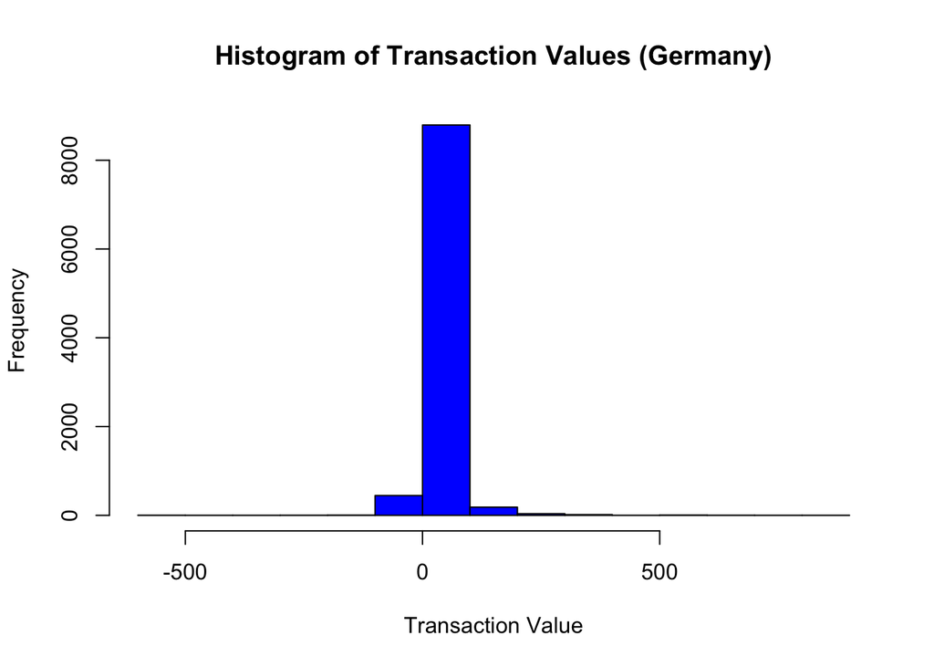

```r
GermanyTransactions <- subset(Online_Retail, Country == "Germany")
hist(GermanyTransactions$TransactionValues,  main = "Histogram of Transaction Values (Germany)", xlab = "Transaction Value", ylab = "Frequency",col = "blue")
```

# Q6)Which customer had the highest number of transactions? Which customer is most valuable (i.e.highest total sum of transactions)?

```r
Online_Retail %>%
  group_by(CustomerID) %>%
  summarise(transactions = n()) %>%
  top_n(2) %>%
  arrange(desc(transactions))
```

```
## # A tibble: 2 × 2
##   CustomerID transactions
##        <int>        <int>
## 1         NA       135080
## 2      17841         7983
```

```r
Online_Retail %>%
  group_by(CustomerID) %>%
  summarise(transaction_sum = sum(TransactionValues)) %>%
  top_n(2) %>%
  arrange(desc(transaction_sum))
```

```
## # A tibble: 2 × 2
##   CustomerID transaction_sum
##        <int>           <dbl>
## 1         NA        1447682.
## 2      14646         279489.
```

#Q7)Calculate the percentage of missing values for each variable in the dataset

```r
missingvalues= colMeans(is.na(Online_Retail))*100
missingvalues
```

```
##         InvoiceNo         StockCode       Description          Quantity
##           0.00000           0.00000           0.00000           0.00000
##       InvoiceDate         UnitPrice        CustomerID           Country
##           0.00000           0.00000          24.92669           0.00000
## TransactionValues
##           0.00000
```

#Q8)What are the number of transactions with missing CustomerID records by countries?

```r
missingCustomer = Online_Retail[is.na(Online_Retail$CustomerID),]
table(missingCustomer$Country)
```

```
##
##        Bahrain           EIRE         France      Hong Kong         Israel
##              2            711             66            288             47
##       Portugal    Switzerland United Kingdom    Unspecified
##             39            125         133600            202
```

#9)On average, how often the costumers comeback to the website for their next shopping? (i.e. what is the average number of days between consecutive shopping)

```r
# Assuming 'Invoice Date' is in a date format
Online_Retail$InvoiceDate <- as.Date(Online_Retail$InvoiceDate)

# Sort the data by CustomerID and InvoiceDate
Online_Retail <- Online_Retail %>%
  arrange(CustomerID, InvoiceDate)

# Calculate the time difference between consecutive transactions for each customer
time_diff <- Online_Retail %>%
  group_by(CustomerID) %>%
  mutate(DaysBetween = as.numeric(difftime(InvoiceDate, lag(InvoiceDate), units = "days")))

# Remove the first row for each customer since there is no previous transaction
time_diff <- time_diff %>%
  filter(!is.na(DaysBetween))

# Calculate the average number of days between consecutive shopping trips
average_days_between_shopping <- mean(time_diff$DaysBetween, na.rm = TRUE)

# Display the result
print(average_days_between_shopping)
```

```
## [1] 14.98301
```

#10)In the retail sector, it is very important to understand the return rate of the goods purchased by customers. In this example, we can define this quantity, simply, as the ratio of the number of transactions cancelled (regardless of the transaction value) over the total number of transactions.With this definition, what is the return rate for the French customers? Consider the cancelled transactions as those where the ‘Quantity’ variable has a negative value.

```r
Francetransactions_Cancelled <- subset(Online_Retail, Country == "France" & Quantity < 0)
Francetransactions <- subset(Online_Retail, Country == "France")
France_Returnrate <- 100*(nrow(Francetransactions_Cancelled) / nrow(Francetransactions))
France_Returnrate
```

```
## [1] 1.741264
```

#Q11)What is the product that has generated the highest revenue for the retailer? (i.e. item with the highest total sum of ‘TransactionValue’).

```r
Product_revenue= Online_Retail %>% group_by(StockCode) %>% summarise(Sum_transactionvalue = sum(TransactionValues))
Product_revenue[which.max(Product_revenue$Sum_transactionvalue),]
```

```
## # A tibble: 1 × 2
##   StockCode Sum_transactionvalue
##   <chr>                    <dbl>
## 1 DOT                    206245.
```

#Q 12)How many unique customers are represented in the dataset? You can use unique() and length()functions.

```r
uniquecustomers <- unique(Online_Retail$CustomerID)
number_of_uniquecustomers <- length(uniquecustomers)
print(number_of_uniquecustomers)
```

```
## [1] 4373
```